# Weekly Assignment 11

Vidushi Kataria

1  
vk412@scarletmail.rutgers.edu

Abstract

```r
# Seed for random number generation
set.seed(42)
knitr::opts_chunk$set(cache.extra = knitr::rand_seed)
```

```r
library(tidyverse)
library(ggdist)
probtask <- read_csv("data/MFIndD_probtask.csv")
```

# Introduction & Research Objectives

Comparing proportions is sometimes very hard! But, even infants seem to be able to do it a little bit. The purpose of this science project was to better understand how well people compare proportions when they are presented in different formats. Such insights contribute to the broader understanding of decision-making processes and the role of stimulus presentation in cognitive tasks.

This study aims to address the following research questions: 1. Does average performance vary across format type? 2. Does average performance vary across numerator congruency status? 3. Does numerator congruency vary across format type? (i.e., is there an interaction)

# Method

A total of 99 adults participated in the study.

First, participants were introduced to a story about a magic ball and that the outcome (i.e., blue or orange) depended on the proportions. They were then asked to compare the proportions of different images.

In other words, participants were shown two images of the same kind at the same time and were asked to decide which had a higher proportion of the shape (or dots) colored in blue.

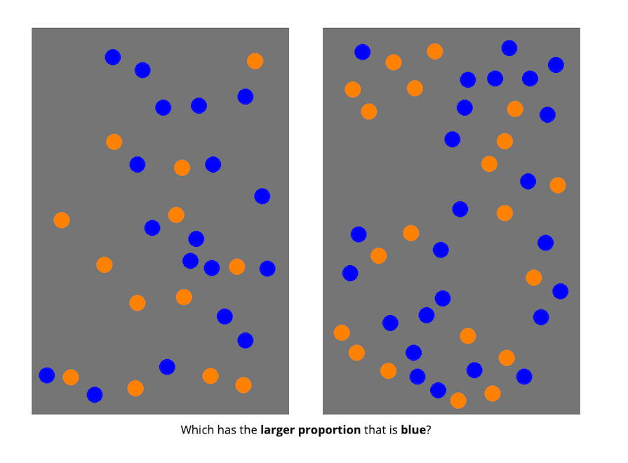

There were four different conditions that changed what kinds of images the participants saw:

- divided blobs: blue and orange were entirely separate
- integrated blob: one blob, divided to be part blue and part orange
- separated dots: blue and orange dots were on opposite sides of the image
- integrated dots: blue and orange were intermixed

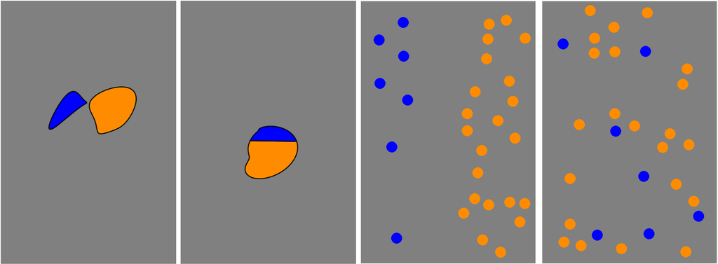

# Results

1. Does average performance vary across format type, ignoring all other aspects of the stimuli?

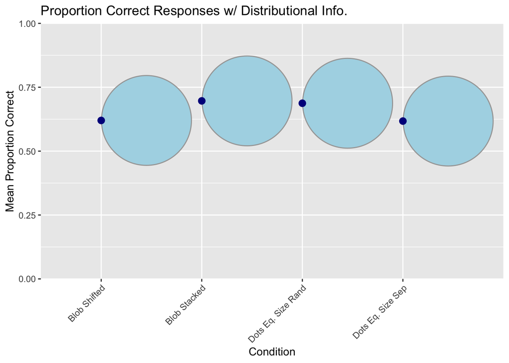

This plot is measuring proportion correct responses with distributional information.

```r
dist_plot <- accuracy_sum %>%
  ggplot(aes(x = condition, y = mean_prop_corr)) +
  stat_dotsinterval(aes(y = mean_prop_corr),
                    color = "darkblue", # consistent color for interval points
                    slab_fill = "lightblue", # show soft contrast in slab,
                    dotsize = 0.6) + # adjusting dot size
  scale_x_discrete(labels = c(
    "blob_shifted" = "Blob Shifted",
    "blob_stacked" = "Blob Stacked",
    "dots_EqSizeRand" = "Dots Eq. Size Rand",
    "dots_EqSizeSep" = "Dots Eq. Size Sep")) +
  scale_y_continuous(limits = c(0, 1), expand = c(0, 0)) +
  labs(title = "Proportion Correct Responses w/ Distributional Info.",
       x = "Condition", y = "Mean Proportion Correct") +
  theme(axis.text.x = element_text(angle = 45, hjust = 1))

dist_plot
```

2. How are reaction time and accuracy related?

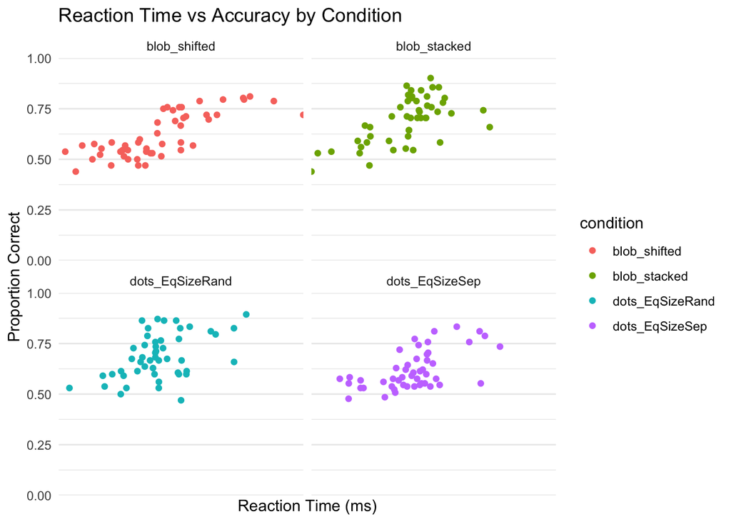

This plot is measuring reaction time and its impact on accuracy by condition.

```r
ggplot(summary_probtask, aes(x = rt, y = correct, color = condition)) +
  geom_point() +
  facet_wrap(~condition) +
  scale_x_discrete(labels = c(
    "blob_shifted" = "Blob Shifted",
    "blob_stacked" = "Blob Stacked",
    "dots_EqSizeRand" = "Dots Eq. Size Rand",
    "dots_EqSizeSep" = "Dots Eq. Size Sep")) +
  scale_y_continuous(limits = c(0, 1), expand = c(0, 0)) +
  labs(
    title = "Reaction Time vs Accuracy by Condition",
    x = "Reaction Time (ms)",
    y = "Proportion Correct") +
  theme_minimal()
```

3. How does numerator congruency interact with format type?

[figure not shown]

```r
plot <- ggplot(plot_data, aes(x = condition, y = proportion_correct,
                      color = num_congruent)) +
  stat_halfeye(alpha = 0.6, side = "both", adjust = 1) +
  scale_x_discrete(labels = c(
    "blob_shifted" = "Blob Shifted",
    "blob_stacked" = "Blob Stacked",
    "dots_EqSizeRand" = "Dots Eq. Size Rand",
    "dots_EqSizeSep" = "Dots Eq. Size Sep")) +
  labs(
    x = "Condition",
    y = "Proportion Correct",
    color = "Numerator Congruency") +
  theme_minimal() +
  theme(axis.text.x = element_text(angle = 45, hjust = 1))

print(plot)
```

[output not shown]

## Data analysis

We used R (Version 4.3.0; R Core Team 2023) and the R-packages *dplyr* (Version 1.1.4; Wickham et al. 2023), *forcats* (Version 1.0.0; Wickham 2023), *ggdist* (Version 3.3.2; Kay 2024), *ggplot2* (Version 3.5.1; Wickham 2016), *lubridate* (Version 1.9.3; Grolemund and Wickham 2011), *papaja* (Version 0.1.3; Aust and Barth 2024), *purrr* (Version 1.0.2; Wickham and Henry 2023), *readr* (Version 2.1.4; Wickham, Hester, and Bryan 2023), *stringr* (Version 1.5.0; Wickham 2022), *tibble* (Version 3.2.1; Müller and Wickham 2023), *tidyr* (Version 1.3.1; Wickham, Vaughan, and Girlich 2024), *tidyverse* (Version 2.0.0; Wickham et al. 2019) and *tinylabels* (Version 0.2.4; Barth 2023) for all our analyses.

# Discussion

The three key findings from these three objectives are **format effect** (blobs vs. dots), **speed-accuracy relationship**, and the **numerator congruency effect**. The choice between blob or dots format does not appear to meaningfully impact performance accuracy. There appears to be a speed-accuracy tradeoff, where participants who took more time tended to achieve a higher accuracy. However, there was some variation in the blob_stacked and dots_EqSizeSep formats. There was also a consistent pattern that emerged across all visualization types where performance was superior when the numerator aligned with the overall ratio.

1. Personally, the most annoying thing about this assignment (and making posters/presentations in R in general) is not knowing what is going to print before knitting. I think labeling code chunks can be a pain as well. But at least R tells you immediately after knitting what the issue is.
2. The most satisfying thing about this assignment is seeing everything you intend to print while knitting your poster.

# References

Aust, Frederik, and Marius Barth. 2024. *papaja: Prepare Reproducible APA Journal Articles with R Markdown*. https://doi.org/10.32614/CRAN.package.papaja.

Barth, Marius. 2023. *tinylabels: Lightweight Variable Labels*. https://cran.r-project.org/package=tinylabels.

Grolemund, Garrett, and Hadley Wickham. 2011. “Dates and Times Made Easy with lubridate.” *Journal of Statistical Software* 40 (3): 1–25. https://www.jstatsoft.org/v40/i03/.

Kay, Matthew. 2024. “ggdist: Visualizations of Distributions and Uncertainty in the Grammar of Graphics.” *IEEE Transactions on Visualization and Computer Graphics* 30 (1): 414–24. https://doi.org/10.1109/TVCG.2023.3327195.

Müller, Kirill, and Hadley Wickham. 2023. *Tibble: Simple Data Frames*. https://CRAN.R-project.org/package=tibble.

R Core Team. 2023. *R: A Language and Environment for Statistical Computing*. Vienna, Austria: R Foundation for Statistical Computing. https://www.R-project.org/.

Wickham, Hadley. 2016. *Ggplot2: Elegant Graphics for Data Analysis*. Springer-Verlag New York. https://ggplot2.tidyverse.org.

———. 2022. *Stringr: Simple, Consistent Wrappers for Common String Operations*. https://CRAN.R-project.org/package=stringr.

———. 2023. *Forcats: Tools for Working with Categorical Variables (Factors)*. https://CRAN.R-project.org/package=forcats.

Wickham, Hadley, Mara Averick, Jennifer Bryan, Winston Chang, Lucy D’Agostino McGowan, Romain François, Garrett Grolemund, et al. 2019. “Welcome to the tidyverse.” *Journal of Open Source Software* 4 (43): 1686. https://doi.org/10.21105/joss.01686.

Wickham, Hadley, Romain François, Lionel Henry, Kirill Müller, and Davis Vaughan. 2023. *Dplyr: A Grammar of Data Manipulation*. https://CRAN.R-project.org/package=dplyr.

Wickham, Hadley, and Lionel Henry. 2023. *Purrr: Functional Programming Tools*. https://CRAN.R-project.org/package=purrr.

Wickham, Hadley, Jim Hester, and Jennifer Bryan. 2023. *Readr: Read Rectangular Text Data*. https://CRAN.R-project.org/package=readr.

Wickham, Hadley, Davis Vaughan, and Maximilian Girlich. 2024. *Tidyr: Tidy Messy Data*. https://CRAN.R-project.org/package=tidyr.